# ARIMA and FFT fit

```r
library(data.table)
library(TSA)
```

[output not shown]

Primero se analizará la serie de tiempo vía modelos ARIMA y luego una FFT.

# EDA

Se ajustarán los datos de los últimos 70 días, debido a que son los que tienen más pronunciada su estacionalidad. La fecha de corte fue el 25 de mayo del 2020.

```r
# read data
df_trans <- read.csv(file = 'Data/trans_all.csv', header = TRUE, stringsAsFactors = FALSE) %>% map_df(rev)
n <- nrow(df_trans)
trans60 <- df_trans[(n-69):n, 'num_trans'] %>% as.matrix()

# parse data to ts object (forecast)
# create daily times from
inds <- seq(as.Date('2020-03-06'), as.Date('2020-05-24'), by = 'day')
ts_trans <- ts(trans60, start = c(2020, as.numeric(format(inds[1], '%j'))), frequency = 7)
```

Graficamos la serie de tiempo y su posible estacionalidad

```r
# plot time series
plot.ts(ts_trans)
autoplot(ts_trans, color = 'navy') + xlab('Tiempo') + ylab('Transacciones') +  theme_minimal() + theme(axis.text.x = element_blank(), legend.position = "none") + ggtitle('Serie de tiempo')
# plot seasonality
# linear
ggseasonplot(ts_trans, season.labels = TRUE, show.legend = FALSE) +xlab('Día de la semana') + ylab('Transacciones') +  theme_minimal() + ggtitle('Serie de tiempo estacional sin nivel') + theme(legend.position = "none")

#polar
ggseasonplot(ts_trans, season.labels = TRUE, polar = TRUE) +xlab('Día de la semana') + ylab('Transacciones') +  theme_minimal() + ggtitle('Serie de tiempo estacional sin nivel') +  theme(legend.position = "none")

# mean value by day
ggsubseriesplot(ts_trans) + xlab('Tiempo') + ylab('Transacciones') +  theme_minimal() +  ggtitle('Serie de tiempo estacionalizada sin nivel')

#lag plots
gglagplot(ts_trans) # look all the noise except for lag 7

# data-seasonal-trend-reminder
descomposedTS <- stl(ts_trans[,'num_trans'], s.window = 'periodic')
descomposedTS %>% autoplot()
```

[output not shown]

## Estacionar la serie e inducir normalidad

### Tranformación Box-Cox

Usamos el método de Victor Guerrero para encontrar la transofrmación estabilizadora de varianza

```r
# lambda
lambda <- ts_trans %>%  BoxCox.lambda(method = 'guerrero') # lambda = 1 ==> no more changes
```

### Diferenciación

```r
(ndif <- ndiffs(ts_trans)) #0
```

```
[1] 0
```

```r
(p <- periodogram(ts_trans))
```

[output not shown]

# FFT Analisis

## Frequency domain observations.

*NOTA:*

- NO SE PORQUÉ, pero el primer término lo debemos quitar. Creo que es porque en la matriz de la FFT, el primer renglon son 1’s y entonces sería como el “promedio espectral” y pues no tiene mucho sentido.
- Como $n$ es par, solo necesitamos la mitad de la info para tomar la frecuencia
- Se me hace muy raro los datos del 30 a 40 queda en 0.

Observamos estacionalidad “decreciente” (valores mayores a 7.5)

Como no empieza en domingo la serie, está desfazado por **dos** días la estacionalidad. Vemos que si hay, aunque tenue, periodicidad cada 7 días en jueves. Como el EDA de series de tiempo proponía.

```r
# fast fourier transform
n <- 70 # total data
df_fft <- data.frame(coef = fft(trans60) / 70, freqindex = 1:70)

# look to the spectrum
df_fft[2:n,] %>%
  ggplot(aes(freqindex, Mod(num_trans))) +
  geom_line(color = 'black') +
  geom_point(color = 'red') +
  xlab('Índice de frecuencia') +
  ylab('Módulo complejo') +
  theme_minimal()

# identify peaks
df_fft[ Mod(df_fft$num_trans) > 7.5 & df_fft$freqindex < n/2, 'freqindex' ] - 1
```

[output not shown]

## Fourier y series de tiempo

```r
nff <-  function(x = NULL, n = NULL, up = 10L, plot = TRUE, add = FALSE, main = NULL, ...){
  #size of the signal
  N <- length(x)

  #The direct transformation
  #The first frequency is DC, the rest are duplicated
  dff <-  fft(x)
  #The time
  t <-  seq(from = 1, to = N)
  #Upsampled time
  nt <-  seq(from = 1, to = N+1-1/up, by = 1/up)

  #New spectrum
  ndff <-  array(data = 0, dim = c(length(nt), 1L))
  ndff[1] <-  dff[1] #Always, it's the DC component
  if(n != 0){
    ndff[2:(n+1)] <-  dff[2:(n+1)] #The positive frequencies always come first
    #The negative ones are trickier
    ndff[length(ndff):(length(ndff) - n + 1)] <-  dff[N:(N - n + 1)]
  }

  #The inverses
  indff <-  fft(ndff/N, inverse = TRUE) ### !
  idff <-  fft(dff/N, inverse = TRUE) ### ! N - 73
  if(plot){
    if(!add){
      plot(x = t, y = x, pch = 16L, xlab = "Tiempo", ylab = "Transacciones",
        main = ifelse(is.null(main), paste(n, "armónicas"), main))
      lines(y = Mod(idff), x = t, col = adjustcolor(1L, alpha = 0.5))
    }
    lines(y = Mod(indff), x = nt, ...)
  }
  ret <-  data.frame(time = nt, y = Mod(indff))
  return(ret)
}
```

```r
# look different number of armonics
nff(x = trans60, n = 7L, up = 70L, col = 2L)
nff(x = trans60, n = 14L, up = 200L, col = 'navy')
nff(x = trans60, n = 20L, up = 200L, col = '#FDE725FF')
```

[output not shown]

Grafiquemos todas las armónicas

(hay que citar a este gran wei https://stackoverflow.com/questions/41435777/perform-fourier-analysis-to-a-time-series-in-r/41465250)

```r
colors <- viridis::viridis(15)
for(i in 1:15){
  ad = ifelse(i == 1, FALSE, TRUE)
  nff(x = trans60, n = i, up = 100L, col = colors[i], add = ad, main = "Todos los wavelets hasta la armónica 15")
}
```

[output not shown]

# ARIMA

Ahora construimos el modelo ARIMA. Sabemos de antemano que $\lambda = 1$ y que $\nabla = 0$, por lo que se trabajará con la serie original.

Al ver la AC y ACP de la serie de tiempo, es razonable pensar en un modelo ARMA({1,2},{4})Est({7})Season, pero veamos el modelo que el algoritmo escoje.

Vemos que el modelo que escoje es un modelo MA1, este modelo lo modemos pasar como AR($\infty$), (desarrollar serie geométrica). Esto puede explicar la transaccionalidad como una función de ellas mismas con respecto al *periodo* pasado, no al día anterior.

```r
# recomended model from forecast package
#fit1 <- auto.arima(ts_trans, approximation = FALSE,  stepwise = FALSE) # harder search
fit2 <- auto.arima(ts_trans) # simpler search
#fit1
fit2
```

```
Series: ts_trans
ARIMA(0,0,0)(0,1,1)[7] with drift

Coefficients:
         sma1   drift
      -0.8742  0.6680
s.e.   0.2418  0.2249

sigma^2 estimated as 1415:  log likelihood=-321.72
AIC=649.43   AICc=649.84   BIC=655.86
```

Por lo anterior, hacemos el ajuste del modelo ARIMA(0,0,0)(0,1,1)[7]

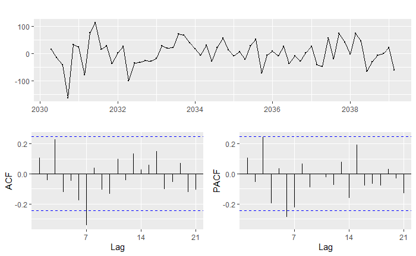

```r
# look ACF and PACF
ts_trans %>% diff(lag = 7) %>% ggtsdisplay()
```

```r
#ggtsdisplay(fit2)
```

Vemos que efectivamente es un modelo ARIMA(0,0,0)(0,1,1)[7], aunque pudiera pensarse también en un ARIMA(3,0,0)(1,1,0)[7] cuyos coeficientes 1 y 2 son ceros. Por tanto trabajaremos con *fit2* (si da tiempo metemos este ultimo modelo).

## Check assumptions

Por las graficas a continuación, la prueba Q-Ljung-Box y los valores atípicos, tenemos un modelo “válido”.

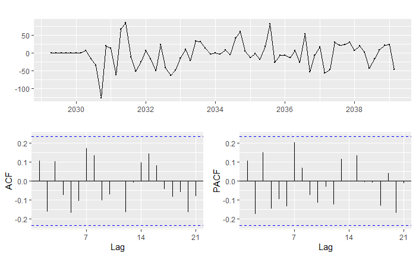

```r
# 1. ACF & PACF for residuals
fit2 %>% residuals() %>% ggtsdisplay() #looks good
```

```
    Ljung-Box test

data:  Residuals from ARIMA(0,0,0)(0,1,1)[7] with drift
Q* = 15.619, df = 12, p-value = 0.2093

Model df: 2.   Total lags used: 14
```

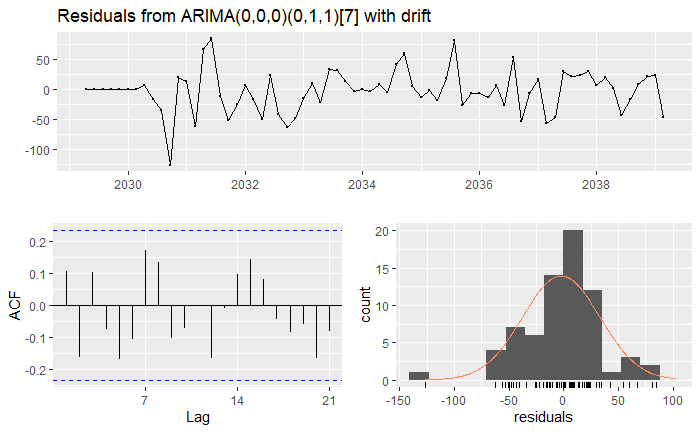

```r
# 2. Check normality
fit2 %>% checkresiduals() #p-value 0.2, ok
```

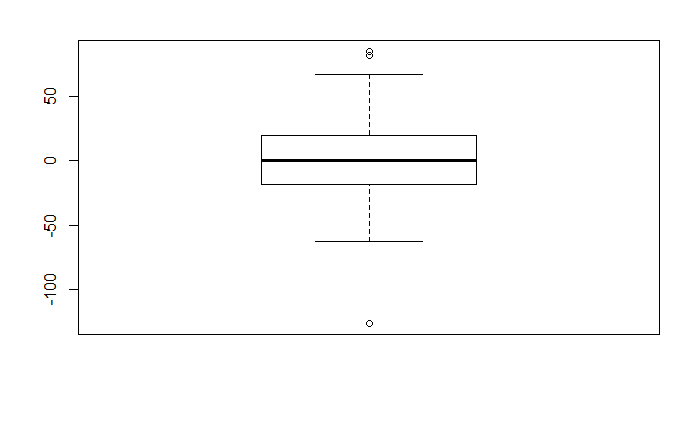

```r
# 3. Look outliers
fit2 %>% residuals() %>% boxplot() # 3 outliers
```

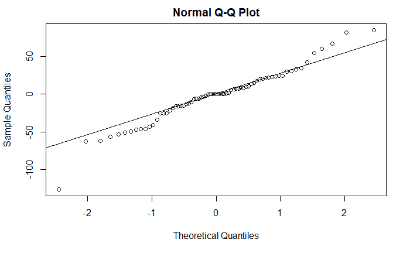

```r
fit2 %>% residuals() %>% qqnorm() # 3 outliers
fit2 %>% residuals() %>% qqline()
```

## Ajuste visual

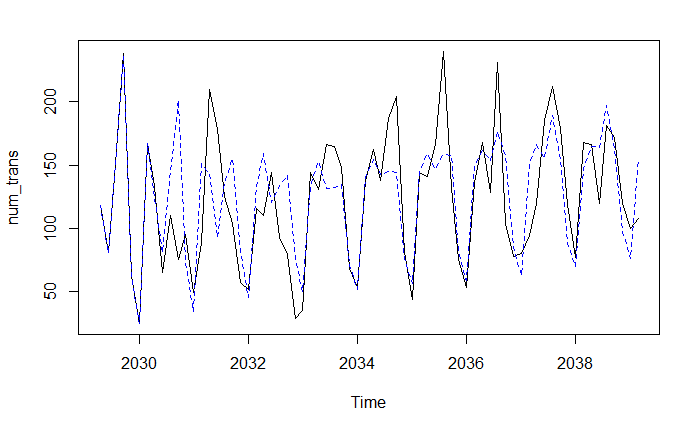

```r
# plot
# serie original con una diferencia
serie <- diff(ts_trans, differences = 1, lag = 7)

plot(fit2$x)
#lines(ts_trans, col = "red")
lines(fitted(fit2),col="blue", lty = 2, lwd = 0.5)
```

## Predicción

Predecimos para las dos semanas con doble IC al nivel 80% y 95%.

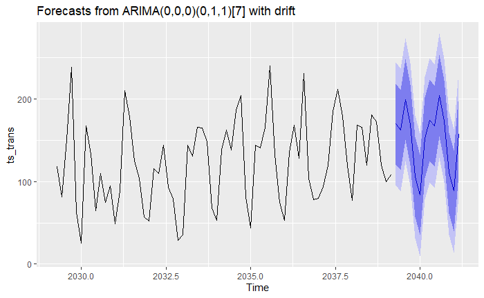

```r
# forecast
fit2 %>% forecast(h = 14, level = c(80,95)) %>% autoplot()
```

```r
NA
NA
```

# Modelo de regresión dinámico armónico

A continuación ajustaremos un modelo armónico con error ARIMA. Los coeficientes de fourier sólamente pueden llegar hasta $m/2$, donde m siginifca el periodo.

```r
fit4 <- auto.arima(ts_trans, xreg = fourier(ts_trans, frequK = 3),
                   seasonal = TRUE, lambda = 1, stepwise = FALSE,
                   approximation = FALSE)  # K = i number of harmonics
```

[output not shown]

## Ajuste visual

[figure not shown]

# TBATS: Modelo trigonométrico, BoxCox, Autoregresivo, estacional.

```r
# tbats model
(fit3 <- ts_trans %>% tbats(use.box.cox = FALSE))
```

```
TBATS(1, {0,0}, -, {<7,2>})

Call: tbats(y = ., use.box.cox = FALSE)

Parameters
  Alpha: 0.08671607
  Gamma-1 Values: 0.01443085
  Gamma-2 Values: 0.01665699

Seed States:
           [,1]
[1,] 109.272712
[2,]  18.227639
[3,]   6.395978
[4,]  41.828083
[5,] -26.286184

Sigma: 34.30725
AIC: 808.3446
```

## Ajuste visual

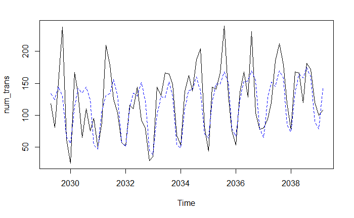

```r
plot(fit3$y)
lines(fitted(fit3),col="blue", lty = 2, lwd = 0.5)
```

Comparación entre modelos

```r
plot(ts_trans, main ="Serie original vs Modelos", ylab = "Transacciones", xlab = "Tiempo")
lines(fit2$fitted, col = "blue", lty = 2)
```

```r
lines(fit4$fitted, col = "green", lty = 2)
lines(fit3$fitted.values, col = "red", lty = 2)
```

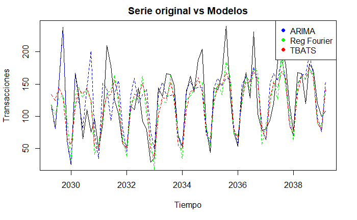

```r
legend("topright",legend=c("ARIMA", "Reg Fourier", "TBATS"), lty=c(0,0), pch=c(16, 16), col=c("blue", "green", "red"))
```

Múltiples predicciones

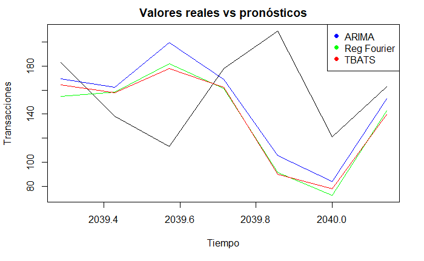

```r
txnNuevas <- read.csv(file = 'Data/lastTrans.csv', header = TRUE, stringsAsFactors = FALSE)
txns <- ts(txnNuevas$num_trans, start = c(2039,3), frequency = 7)

pronos1 <- forecast(fit2, h = 7,level = 80)
pronos2 <- forecast(fit4, xreg = fourier(ts_trans, K = 3,h = 7),level = 80)
pronos3 <- forecast(fit3, h = 7,level = 80)
ts.plot(txns,pronos1$mean,pronos2$mean, pronos3$mean, gpars = list(col = c("black", "blue", "green", "red"),main ="Valores reales vs pronósticos", ylab = "Transacciones", xlab = "Tiempo"))
legend("topright",legend=c("ARIMA", "Reg Fourier", "TBATS"), lty=c(0,0), pch=c(16, 16), col=c("blue", "green", "red"))
```

Calidad de los pronósticos

```r
accuracy(pronos1,txns)
```

```
                    ME     RMSE      MAE        MPE     MAPE      MASE      ACF1
Training set -2.323167 35.11526 25.25892 -9.2648837 24.08213 0.7016366 0.1058344
Test set      8.929573 54.10378 40.59534  0.6728448 27.58100 1.1276485 0.2864742
             Theil's U
Training set        NA
Test set      1.026521
```

```r
accuracy(pronos2,txns)
```

```
                    ME     RMSE      MAE       MPE     MAPE      MASE       ACF1
Training set  4.793335 32.94559 25.68907 -2.501271 23.77990 0.7135853 -0.0500315
Test set     20.276423 57.01475 45.74777  8.252809 29.86748 1.2707715  0.3005000
             Theil's U
Training set        NA
Test set      1.031225
```

```r
accuracy(pronos3,txns)
```

```
                    ME     RMSE      MAE       MPE     MAPE      MASE      ACF1
Training set  4.825218 34.30725 26.62298 -4.200905 23.80446 0.7395271 0.0487226
Test set     19.294754 55.57810 43.34273  7.741814 28.12775 1.2039647 0.2985667
             Theil's U
Training set        NA
Test set      1.014523
```